# Proyecto EasyVisa

## Contexto:

Las comunidades empresariales en los Estados Unidos se enfrentan a una gran demanda de recursos humanos, pero uno de los desafíos constantes es identificar y atraer el talento adecuado, que es quizás el elemento más importante para seguir siendo competitivo. Las empresas en los Estados Unidos buscan personas trabajadoras, talentosas y calificadas tanto a nivel local como en el extranjero.

La Ley de Inmigración y Nacionalidad (INA) de los EE. UU. permite que los trabajadores extranjeros vengan a los Estados Unidos a trabajar de manera temporal o permanente. La ley también protege a los trabajadores estadounidenses contra impactos adversos en sus salarios o condiciones de trabajo al garantizar el cumplimiento de los requisitos legales por parte de los empleadores estadounidenses cuando contratan trabajadores extranjeros para cubrir la escasez de mano de obra. Los programas de inmigración son administrados por la Oficina de Certificación de Trabajo Extranjero (OFLC).

OFLC procesa las solicitudes de certificación laboral para los empleadores que buscan traer trabajadores extranjeros a los Estados Unidos y otorga certificaciones en aquellos casos en los que los empleadores pueden demostrar que no hay suficientes trabajadores estadounidenses disponibles para realizar el trabajo con salarios que alcanzan o superan el salario pagado por la ocupación. en el área de empleo previsto.

## Objetivo:

En el año fiscal 2016, la OFLC procesó 775 979 solicitudes de empleadores para 1 699 957 puestos para certificaciones laborales temporales y permanentes. Este fue un aumento del nueve por ciento en el número total de solicitudes procesadas con respecto al año anterior. El proceso de revisión de cada caso se está convirtiendo en una tarea tediosa ya que el número de solicitantes aumenta cada año.

El creciente número de solicitantes cada año requiere una solución basada en aprendizaje automático que pueda ayudar a preseleccionar a los candidatos que tienen mayores posibilidades de aprobación de VISA. OFLC ha contratado a su empresa EasyVisa para soluciones basadas en datos. Usted, como científico de datos, debe analizar los datos proporcionados y, con la ayuda de un modelo de clasificación:

*Facilitar el proceso de aprobación de visas.* Recomendar un perfil adecuado para los solicitantes a quienes se les debe certificar o denegar la visa en función de los factores que influyen significativamente en el estado del caso.

## Datos Descripción

Los datos contienen los diferentes atributos del empleado y del empleador. El diccionario de datos detallado se proporciona a continuación.

- case_id: ID de cada solicitud de visa
- continent: Información del continente del empleado
- education_of_employee: Información de educación del empleado
- has_job_experience: ¿El empleado tiene alguna experiencia laboral? S= Sí; N = No
- require_job_training: ¿El empleado requiere alguna capacitación laboral? S = Sí; N = No
- no_de_employees: Número de empleados en la empresa del empleador
- yr_of_estab: Año en que se constituyó la empresa del empleador
- region_of_employment:: información de la región prevista de empleo del trabajador extranjero en los EE. UU.
- prevailing_wage: Salario promedio pagado a trabajadores empleados de manera similar en una ocupación específica en el área de empleo prevista. El propósito del salario prevaleciente es asegurar que el trabajador extranjero no esté mal pagado en comparación con otros trabajadores que ofrecen el mismo servicio o un servicio similar en la misma área de empleo.
- unit_of_wage: Unidad de salario prevaleciente. Los valores incluyen por salario por hora, Semanal, Mensual y Anual.
- full_time_position: ¿El puesto de trabajo es de tiempo completo? Y = Puesto de tiempo completo; N = Puesto a tiempo parcial
- case_status: Indicador que indica si la Visa fue certificada o denegada

## Importación de bibliotecas y datos necesarios

```python
#Instalación de bibliotecas
!pip install sklearn -U
!pip install xgboost -U
```

```python
# Librerias para manipular datos
import numpy as np
import pandas as pd

# Librerias para visualización
import matplotlib.pyplot as plt
%matplotlib inline
import seaborn as sns



# libreria para dividir data
from sklearn.model_selection import train_test_split

# Para el modelo de predicción "ensemble classifiers" Baggin/Ramdon Forest/Bossting
from sklearn import tree
from sklearn.tree import DecisionTreeClassifier


# Para el modelo de predicción
from sklearn.ensemble import (
    BaggingClassifier,
    RandomForestClassifier,
    AdaBoostClassifier,
    GradientBoostingClassifier,
    StackingClassifier,
)

from xgboost import XGBClassifier

from sklearn.model_selection import GridSearchCV

# Para métricas de rendimiento
from sklearn import metrics
from sklearn.metrics import confusion_matrix, classification_report
from sklearn.metrics import accuracy_score,precision_score,recall_score,f1_score, roc_auc_score
import scipy.stats as stats

import warnings
warnings.filterwarnings('ignore')

# ajuste a  3 decimal points
pd.set_option("display.float_format", lambda x: "%.3f" % x)
```

## Lectura del conjunto de datos

```python
hr=pd.read_csv("EasyVisa.csv")
```

```python
#Copiar el conjunto de datos para evitar cambios en la data original
data=hr.copy()
```

## Resumen de datos

- Observaciones
- Controles de cordura

```python
# Visualización primeras filas de datos
data.head()
```

|  | case_id | continent | education_of_employee | has_job_experience | requires_job_training | no_of_employees | yr_of_estab | region_of_employment | prevailing_wage | unit_of_wage | full_time_position | case_status |
| --- | --- | --- | --- | --- | --- | --- | --- | --- | --- | --- | --- | --- |
| 0 | EZYV01 | Asia | High School | N | N | 14513 | 2007 | West | 592.203 | Hour | Y | Denied |
| 1 | EZYV02 | Asia | Master's | Y | N | 2412 | 2002 | Northeast | 83425.650 | Year | Y | Certified |
| 2 | EZYV03 | Asia | Bachelor's | N | Y | 44444 | 2008 | West | 122996.860 | Year | Y | Denied |
| 3 | EZYV04 | Asia | Bachelor's | N | N | 98 | 1897 | West | 83434.030 | Year | Y | Denied |
| 4 | EZYV05 | Africa | Master's | Y | N | 1082 | 2005 | South | 149907.390 | Year | Y | Certified |

```python
# Visualización ultimas filas de datos
data.tail()
```

|  | case_id | continent | education_of_employee | has_job_experience | requires_job_training | no_of_employees | yr_of_estab | region_of_employment | prevailing_wage | unit_of_wage | full_time_position | case_status |
| --- | --- | --- | --- | --- | --- | --- | --- | --- | --- | --- | --- | --- |
| 25475 | EZYV25476 | Asia | Bachelor's | Y | Y | 2601 | 2008 | South | 77092.570 | Year | Y | Certified |
| 25476 | EZYV25477 | Asia | High School | Y | N | 3274 | 2006 | Northeast | 279174.790 | Year | Y | Certified |
| 25477 | EZYV25478 | Asia | Master's | Y | N | 1121 | 1910 | South | 146298.850 | Year | N | Certified |
| 25478 | EZYV25479 | Asia | Master's | Y | Y | 1918 | 1887 | West | 86154.770 | Year | Y | Certified |
| 25479 | EZYV25480 | Asia | Bachelor's | Y | N | 3195 | 1960 | Midwest | 70876.910 | Year | Y | Certified |

- En apariencia, de las primeras y ultimas filas de datos, se puede observar que las columnas presentan datos y tipos de datos que concuerdan con lo esperado.
- La columna case_id contiene valores únicos.
- Se realizarán otros controles posteriores para verificar la información.

```python
# Revisión de la forma de los datos
print("-El conjunto de datos contiene", data.shape[0], 'FILAS y', data.shape[1], "COLUMNAS.")
data.shape
```

```
-El conjunto de datos contiene 25480 FILAS y 12 COLUMNAS.
```

```
(25480, 12)
```

```python
#Verificación de  los tipos de datos de las columnas para el conjunto de datos.
data.info()
```

```
<class 'pandas.core.frame.DataFrame'>
RangeIndex: 25480 entries, 0 to 25479
Data columns (total 12 columns):
 #   Column                 Non-Null Count  Dtype
---  ------                 --------------  -----
 0   case_id                25480 non-null  object
 1   continent              25480 non-null  object
 2   education_of_employee  25480 non-null  object
 3   has_job_experience     25480 non-null  object
 4   requires_job_training  25480 non-null  object
 5   no_of_employees        25480 non-null  int64
 6   yr_of_estab            25480 non-null  int64
 7   region_of_employment   25480 non-null  object
 8   prevailing_wage        25480 non-null  float64
 9   unit_of_wage           25480 non-null  object
 10  full_time_position     25480 non-null  object
 11  case_status            25480 non-null  object
dtypes: float64(1), int64(2), object(9)
memory usage: 2.3+ MB
```

```python
#Revisión de Datos duplicados
data["case_id"].duplicated().value_counts()
```

```
False    25480
Name: case_id, dtype: int64
```

```python
data.isnull().sum()
```

```
case_id                  0
continent                0
education_of_employee    0
has_job_experience       0
requires_job_training    0
no_of_employees          0
yr_of_estab              0
region_of_employment     0
prevailing_wage          0
unit_of_wage             0
full_time_position       0
case_status              0
dtype: int64
```

- No se tienen datos nulos ni duplicados.
- Para evitar el consumo de recursos de memoria, conviene tratar las calumnas tipo objeto como categorias.

### Corrección de los tipos de datos

```python
#Funcion de bucle para convertir variables tipo objeto a categorias
for feature in data.columns:
    if data[feature].dtype == 'object':
        data[feature] = pd.Categorical(data[feature])
data.info(10)
```

```
<class 'pandas.core.frame.DataFrame'>
RangeIndex: 25480 entries, 0 to 25479
Data columns (total 12 columns):
 #   Column                 Non-Null Count  Dtype
---  ------                 --------------  -----
 0   case_id                25480 non-null  category
 1   continent              25480 non-null  category
 2   education_of_employee  25480 non-null  category
 3   has_job_experience     25480 non-null  category
 4   requires_job_training  25480 non-null  category
 5   no_of_employees        25480 non-null  int64
 6   yr_of_estab            25480 non-null  int64
 7   region_of_employment   25480 non-null  category
 8   prevailing_wage        25480 non-null  float64
 9   unit_of_wage           25480 non-null  category
 10  full_time_position     25480 non-null  category
 11  case_status            25480 non-null  category
dtypes: category(9), float64(1), int64(2)
memory usage: 2.0 MB
```

```python
#Verificación de valores únicos por categorias
cols_cat= data.select_dtypes(['category'])
for i in cols_cat.columns:
    print('Unique values in',i, 'are :')
    print(cols_cat[i].value_counts())
    print('*'*50)
```

```
Unique values in case_id are :
EZYV01       1
EZYV25287    1
EZYV25285    1
EZYV25284    1
EZYV25283    1
            ..
EZYV17633    1
EZYV17632    1
EZYV17631    1
EZYV17630    1
EZYV9999     1
Name: case_id, Length: 25480, dtype: int64
Unique values in continent are :
Asia             16861
Europe            3732
North America     3292
South America      852
Africa             551
Oceania            192
Name: continent, dtype: int64
Unique values in education_of_employee are :
Bachelor's     10234
Master's        9634
High School     3420
Doctorate       2192
Name: education_of_employee, dtype: int64
Unique values in has_job_experience are :
Y    14802
N    10678
Name: has_job_experience, dtype: int64
Unique values in requires_job_training are :
N    22525
Y     2955
Name: requires_job_training, dtype: int64
Unique values in region_of_employment are :
Northeast    7195
South        7017
West         6586
Midwest      4307
Island        375
Name: region_of_employment, dtype: int64
Unique values in unit_of_wage are :
Year     22962
Hour      2157
Week       272
Month       89
Name: unit_of_wage, dtype: int64
Unique values in full_time_position are :
Y    22773
N     2707
Name: full_time_position, dtype: int64
Unique values in case_status are :
Certified    17018
Denied        8462
Name: case_status, dtype: int64
```

- De la verificación de valores únicos se puede inferir el posterior tratamiento de los datos.
- En este caso el de las columnas tipo categoria para agilizar la codificación de las variables.

### Resumen del conjunto de datos

```python
#Sumario de datos numéricos
data.describe().T
```

|  | count | mean | std | min | 25% | 50% | 75% | max |
| --- | --- | --- | --- | --- | --- | --- | --- | --- |
| no_of_employees | 25480.000 | 5667.043 | 22877.929 | -26.000 | 1022.000 | 2109.000 | 3504.000 | 602069.000 |
| yr_of_estab | 25480.000 | 1979.410 | 42.367 | 1800.000 | 1976.000 | 1997.000 | 2005.000 | 2016.000 |
| prevailing_wage | 25480.000 | 74455.815 | 52815.942 | 2.137 | 34015.480 | 70308.210 | 107735.513 | 319210.270 |

- La columna no_of_employees, presenta números negativos, esto se deberá revisar para determinar su congruencia ó tratamiento, así mismo se observa que tiene mucha varianza.
- La columna prevailing_wage se deberá por su naturaleza tiene mucha varianza, esta depende de muchos factores como nivel de estudios, tipo de puesto y el área donde se desarrolla la actividad.

```python
#Sumario de categorias de datos
data.describe(include=['category']).T
```

|  | count | unique | top | freq |
| --- | --- | --- | --- | --- |
| case_id | 25480 | 25480 | EZYV01 | 1 |
| continent | 25480 | 6 | Asia | 16861 |
| education_of_employee | 25480 | 4 | Bachelor's | 10234 |
| has_job_experience | 25480 | 2 | Y | 14802 |
| requires_job_training | 25480 | 2 | N | 22525 |
| region_of_employment | 25480 | 5 | Northeast | 7195 |
| unit_of_wage | 25480 | 4 | Year | 22962 |
| full_time_position | 25480 | 2 | Y | 22773 |
| case_status | 25480 | 2 | Certified | 17018 |

- Hay 6 segmentos de procedencia ó continentes,la mayoría de las solicitudes son de Asia.
- La mayoría de las aplicaciones, son de Bachiller ( grado universitario)
- La mayoría de los casos tiene experiencia laboral, y No requieren entrenamiento.
- La región de empleo más popular es la zona Northeast.
- La mayoría de solicitudes, tiene una unidad de pago ó contrato anual para el salario prevaleciente.
- La mayoría de solicitudes, son aplicaciones para trabajos de tiempo completo.
- La mayoría de solicitudes, son aprobadas.

## Análisis exploratorio de datos (EDA)

- EDA es una parte importante de cualquier proyecto que involucre datos.
- Es importante investigar y comprender mejor los datos antes de construir un modelo con ellos.
- A continuación se mencionan algunas preguntas que lo ayudarán a abordar el análisis de la manera correcta y generar conocimientos a partir de los datos.
- Se debe realizar un análisis exhaustivo de los datos, además de las preguntas que se mencionan a continuación.

```python
#Para la creación de histogramas y diagramas de caja estandarizada se ejecuta esta función

def histogram_boxplot(data, feature, figsize=(15, 10), kde=False, bins=None):
    """
    Boxplot and histogram combined

    data: dataframe
    feature: dataframe column
    figsize: size of figure (default (15,10))
    kde: whether to show the density curve (default False)
    bins: number of bins for histogram (default None)
    """
    f2, (ax_box2, ax_hist2) = plt.subplots(
        nrows=2,  # Number of rows of the subplot grid= 2
        sharex=True,  # x-axis will be shared among all subplots
        gridspec_kw={"height_ratios": (0.25, 0.75)},
        figsize=figsize,
    )  # creating the 2 subplots
    sns.boxplot(
        data=data, x=feature, ax=ax_box2, showmeans=True, color="violet"
    )  # boxplot will be created and a triangle will indicate the mean value of the column
    sns.histplot(
        data=data, x=feature, kde=kde, ax=ax_hist2, bins=bins
    ) if bins else sns.histplot(
        data=data, x=feature, kde=kde, ax=ax_hist2
    )  # For histogram
    ax_hist2.axvline(
        data[feature].mean(), color="green", linestyle="--"
    )  # Add mean to the histogram
    ax_hist2.axvline(
        data[feature].median(), color="black", linestyle="-"
    )  # Add median to the histogram
```

```python
#Para la creación de gráficos de barras estandarizada se ejecuta esta función

def labeled_barplot(data, feature, perc=False, n=None):
    """
    Barplot with percentage at the top

    data: dataframe
    feature: dataframe column
    perc: whether to display percentages instead of count (default is False)
    n: displays the top n category levels (default is None, i.e., display all levels)
    """

    total = len(data[feature])  # length of the column
    count = data[feature].nunique()
    if n is None:
        plt.figure(figsize=(count + 2, 6))
    else:
        plt.figure(figsize=(n + 2, 6))

    plt.xticks(rotation=90, fontsize=15)
    ax = sns.countplot(
        data=data,
        x=feature,
        palette="Paired",
        order=data[feature].value_counts().index[:n],
    )

    for p in ax.patches:
        if perc == True:
            label = "{:.1f}%".format(
                100 * p.get_height() / total
            )  # percentage of each class of the category
        else:
            label = p.get_height()  # count of each level of the category

        x = p.get_x() + p.get_width() / 2  # width of the plot
        y = p.get_height()  # height of the plot

        ax.annotate(
            label,
            (x, y),
            ha="center",
            va="center",
            size=12,
            xytext=(0, 5),
            textcoords="offset points",
        )  # annotate the percentage

    plt.show()  # show the plot
```

```python
#Para la creación de diagramas de barra apilados

def stacked_barplot(data, predictor, target):
    """
    Print the category counts and plot a stacked bar chart

    data: dataframe
    predictor: independent variable
    target: target variable
    """
    count = data[predictor].nunique()
    sorter = data[target].value_counts().index[-1]
    tab1 = pd.crosstab(data[predictor], data[target], margins=True).sort_values(
        by=sorter, ascending=False
    )
    print(tab1)
    print("-" * 120)
    tab = pd.crosstab(data[predictor], data[target], normalize="index").sort_values(
        by=sorter, ascending=False
    )
    tab.plot(kind="bar", stacked=True, figsize=(count + 5, 5))
    plt.legend(
        loc="lower left", frameon=False,
    )
    plt.legend(loc="upper left", bbox_to_anchor=(1, 1))
    plt.show()
```

```python
### función para trazar distribuciones vrs al objetivo
def distribution_plot_wrt_target(data, predictor, target):

    fig, axs = plt.subplots(2, 2, figsize=(12, 10))

    target_uniq = data[target].unique()

    axs[0, 0].set_title("Distribution of target for target=" + str(target_uniq[0]))
    sns.histplot(
        data=data[data[target] == target_uniq[0]],
        x=predictor,
        kde=True,
        ax=axs[0, 0],
        color="teal",
        stat="density",
    )

    axs[0, 1].set_title("Distribution of target for target=" + str(target_uniq[1]))
    sns.histplot(
        data=data[data[target] == target_uniq[1]],
        x=predictor,
        kde=True,
        ax=axs[0, 1],
        color="orange",
        stat="density",
    )

    axs[1, 0].set_title("Boxplot w.r.t target")
    sns.boxplot(data=data, x=target, y=predictor, ax=axs[1, 0], palette="gist_rainbow")

    axs[1, 1].set_title("Boxplot (without outliers) w.r.t target")
    sns.boxplot(
        data=data,
        x=target,
        y=predictor,
        ax=axs[1, 1],
        showfliers=False,
        palette="gist_rainbow",
    )

    plt.tight_layout()
    plt.show()
```

**Preguntas capciosas**:

1. Las personas con educación superior pueden querer viajar al extranjero por un trabajo bien remunerado. ¿La educación juega un papel en la certificación de Visa?
2. ¿Cómo varía el estado de la visa en los diferentes continentes?
3. Los profesionales experimentados pueden buscar oportunidades en el extranjero para mejorar su estilo de vida y desarrollo profesional. ¿La experiencia laboral influye en el estado de la visa?
4. En los Estados Unidos, a los empleados se les paga en diferentes intervalos. ¿Qué unidad de pago es más probable que se certifique para una visa?
5. El gobierno de los Estados Unidos ha establecido un salario prevaleciente para proteger el talento local y los trabajadores extranjeros. ¿Cómo cambia el estado de la visa con el salario prevaleciente?
1. Las personas con educación superior pueden querer viajar al extranjero por un trabajo bien remunerado. ¿La educación juega un papel en la certificación de Visa?

```
education_of_employee  Bachelor's  Doctorate  High School  Master's    All
case_status
All                         10234       2192         3420      9634  25480
Certified                    6367       1912         1164      7575  17018
Denied                       3867        280         2256      2059   8462
------------------------------------------------------------------------------------------------------------------------
```

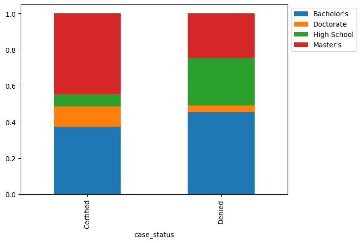

```python
stacked_barplot(data,"case_status","education_of_employee")
```

```
continent    Africa   Asia  Europe  North America  Oceania  South America  \
case_status
All             551  16861    3732           3292      192            852
Certified       397  11012    2957           2037      122            493
Denied          154   5849     775           1255       70            359

continent      All
case_status
All          25480
Certified    17018
Denied        8462
------------------------------------------------------------------------------------------------------------------------
```

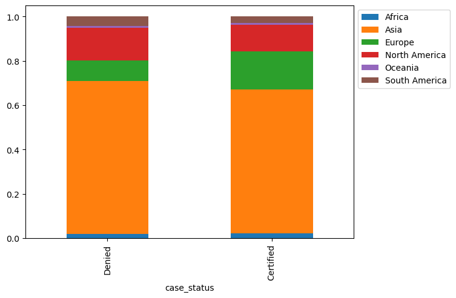

```python
stacked_barplot(data,"case_status","continent")
```

```python
#agrupación estado de la visa en los diferentes continentes
st_continent=(data.groupby(['case_status'])[['continent']])
round(st_continent.value_counts(dropna=False)*100/data.shape[0],2)
```

```
case_status  continent
Certified    Asia            43.220
             Europe          11.610
             North America    7.990
             South America    1.930
             Africa           1.560
             Oceania          0.480
Denied       Asia            22.960
             North America    4.930
             Europe           3.040
             South America    1.410
             Africa           0.600
             Oceania          0.270
dtype: float64
```

- La mayoria de visas denegadas y aceptadas son de Asia. De el total de solicitudes , un 43% se aprobó y un 22% se denegó.
- Europa es el continente seguido de Asia donde más solicitudes se aprobaron, el 11.61 %, y solo un 3% de los rechazos fueron europeos.
- En el Norte América, hay un 8% de visas aprobadas, respecto a un casi 5% de solicitudes rechazadas.
- En el Sur de América 1.93% de las solicitudes se aprobaron,respecto a un 1.41% de solicitudes que fueron rechazadas.
- Debe destacarse que se está diferenciando america del norte y america del sur, no obstante son un mismo continente.
- Continentes como Africa, de donde se recibieron un 2.2% de solicitudes, un 1.56% se certificaron como aprobadas.
- Casi un 0,8% de solicitudes totales, provienen de Oceanía, de las cuales un 0.48% recibieron estatus de aprobación.
1. Los profesionales experimentados pueden buscar oportunidades en el extranjero para mejorar su estilo de vida y desarrollo profesional. ¿La experiencia laboral influye en el estado de la visa?

```
has_job_experience      N      Y    All
case_status
All                 10678  14802  25480
Certified            5994  11024  17018
Denied               4684   3778   8462
------------------------------------------------------------------------------------------------------------------------
```

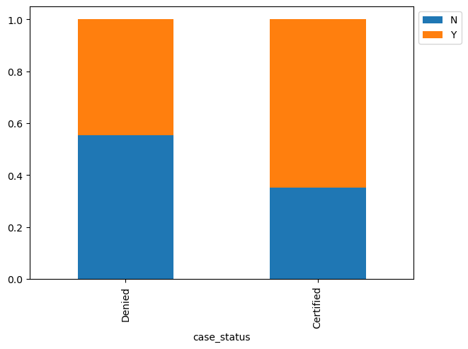

```python
stacked_barplot(data,"case_status","has_job_experience")
```

```python
#agrupación estado de la visa según la experiencia previa
st_continent=(data.groupby(['case_status'])[['has_job_experience']])
round(st_continent.value_counts(dropna=False)*100/data.shape[0],2)
```

```
case_status  has_job_experience
Certified    Y                    43.270
             N                    23.520
Denied       N                    18.380
             Y                    14.830
dtype: float64
```

- Es importante recalcar que depende de la condición que se presente con esta experiencia previa. Por ejemplo, será importante revisar que estado de estudios valora más la experiencia previa, y que combinación de factores pueden inlfuir en la aprobación de la visa si no se tiene estudio ó experiencia previa.

No obstante de la información se puede rescatar que :

- La mayoría de las personas certificadas, tienen experiencia previa.
- Si bien, tener experiencia previa , no garantiza la aprobación de la visa, la mayoría de las visas denegadas corresponden a aplicaciones que no tienen experiencia previa.
- Esto parece indicar que si es importante ó de péso, tener experiencia previa para conseguir una visa.
1. En los Estados Unidos, a los empleados se les paga en diferentes intervalos. ¿Qué unidad de pago es más probable que se certifique para una visa?

```
unit_of_wage  Hour  Month  Week   Year    All
case_status
All           2157     89   272  22962  25480
Certified      747     55   169  16047  17018
Denied        1410     34   103   6915   8462
------------------------------------------------------------------------------------------------------------------------
```

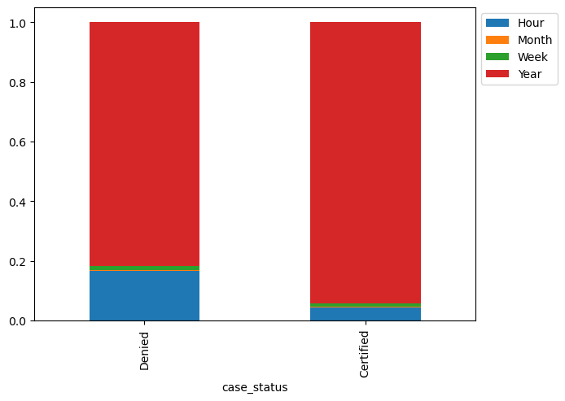

```python
stacked_barplot(data,"case_status","unit_of_wage")
```

```python
#agrupación estado de la visa según la experiencia previa
st_continent=(data.groupby(['case_status'])[['unit_of_wage']])
round(st_continent.value_counts(dropna=False)*100/data.shape[0],2)
```

```
case_status  unit_of_wage
Certified    Year           62.980
             Hour            2.930
             Week            0.660
             Month           0.220
Denied       Year           27.140
             Hour            5.530
             Week            0.400
             Month           0.130
dtype: float64
```

[output not shown]

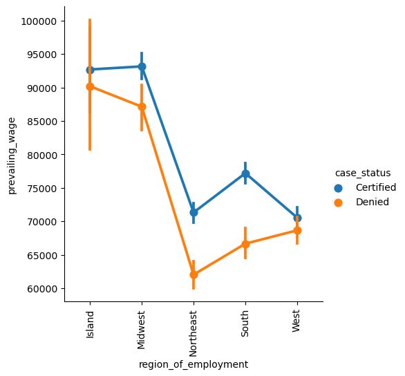

```python
#Observaciones entre salario prevaleciente y la región de trabajo
plt.figure(figsize=(25,15))
sns.catplot(data=data, x='region_of_employment', y='prevailing_wage', hue='case_status', kind='point');
plt.xticks(rotation=90)
```

[output not shown]

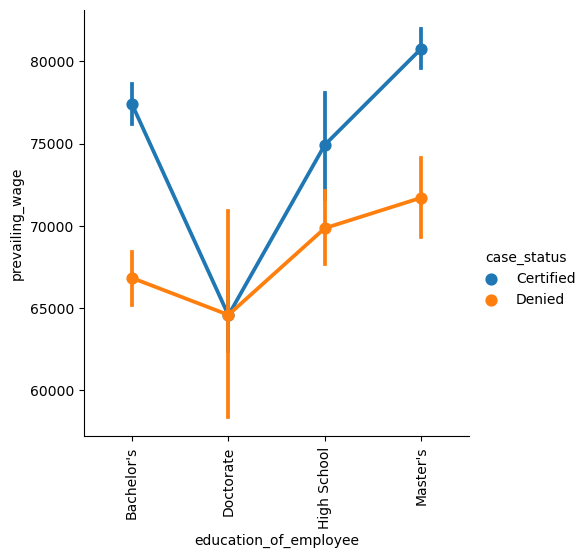

```python
#Observaciones entre salario prevaleciente promedio y la educación
plt.figure(figsize=(25,15))
sns.catplot(data=data, x='education_of_employee', y='prevailing_wage', hue='case_status', kind='point');
plt.xticks(rotation=90)
```

- Regiones como West y Northeast requieren de menor salario prevaleciente promedio ( alrededor de 70000) para obtener visa.
- Regiones como Island y Midwest requieren salarios prevaleciente promedio mayores ( más de 90000) para tener un estatus de visa aprobado.
- La región sur requieren salarios prevaleciente promedio mayores a 75000 para tener un estatus aprobado.
- Respecto al salario prevaleciente, en promedio los trabajadores de regiones como con Island y Mid west, tiene los salarios más altos, y no necesariamente cumplir con este requisito condede la aprobación de la visa.
- La región Northeast, es que que tiene la media menor en cuanto a salarios prevalecientes.
- Para los casos donde los salarios prevalecientes sean mucho mayor sin importar el nivel de estudio, la tendencia es conceder la visa, por ejemplo, para un PHD, es posible que los salarios prevalecientes de la zona no sean apropiados para el nivel de estudio, en este caso la tendencia a aprobar la visa puede no ser beneficioso para el candidato ( casos menores a 70 000 unidades promedio)
- Hay una tendencia en los datos a que salarios prevalecientes de niveles de estudios como High_Scholl, Bachiller, y Master, tienen un estatus aprobado dado que se mantienen sobre las 70 000 unidades en promedio.

### **Nota**: El EDA detallado se puede encontrar en la sección apéndice.

## Preprocesamiento de datos

- Tratamiento de valor perdido (si es necesario)
- Ingeniería de características
- Detección y tratamiento de valores atípicos (si es necesario)
- Preparación de datos para el modelado.
- Cualquier otro paso de preprocesamiento (si es necesario)

## Ingeniería de características

Tanto las variables numéricas como las categóricas se pueden utilizar en árboles de decisión y bosques aleatorios, estos son comúnmente utilizados como estimadores base debido a su flexibilidad y capacidad para modelar relaciones complejas en los datos. Cada estimador base se entrena en un subconjunto aleatorio de los datos de entrenamiento, lo que introduce variabilidad en el proceso de entrenamiento y reduce la probabilidad de sobreajuste.

En el caso del bosque aleatorio, se utiliza una variante específica de bagging donde se entrena un conjunto de árboles de decisión y las predicciones se promedian o se votan para obtener una predicción final. Esto suele conducir a modelos más robustos y generalizables.

Estos estimadores se utilizaran en Bagging, es importante codificar adecuadamente las variables categóricas y comprender cómo funcionan estos modelos en relación con los diferentes tipos de características. En este caso, se experimentará manteniendo todas las variables numéricas, en busca de mejorar el rendimiento del modelo como estrategia de codificación.

```python
#Codificación de variables categóricas
replaceStruct = {
                "requires_job_training":  {"N": 0, "Y": 1 },
                "full_time_position":     {"N": 0, "Y": 1 },
                "has_job_experience":     {"N": 0, "Y": 1 },
                "case_status": {"Certified": 1, "Denied":0},
                    }
oneHotCols=["continent","education_of_employee","region_of_employment", "unit_of_wage"]
```

```python
#Eliminar las columnas que no aportan al modelo
data.drop(['case_id','yr_of_estab', "años_empresa", ],axis=1,inplace=True)
```

```python
data=data.replace(replaceStruct)
data=pd.get_dummies(data, columns=oneHotCols)
```

```python
for feature in data.columns: # Loop through all columns in the dataframe
    if data[feature].dtype == 'category': # Only apply for columns with categorical strings
        data[feature] = pd.to_numeric(data[feature])# Replace strings with an integer*VER NOTA ABAJO
data.head(10)
```

|  | has_job_experience | requires_job_training | no_of_employees | prevailing_wage | full_time_position | case_status | continent_Africa | continent_Asia | continent_Europe | continent_North America | ... | education_of_employee_Master's | region_of_employment_Island | region_of_employment_Midwest | region_of_employment_Northeast | region_of_employment_South | region_of_employment_West | unit_of_wage_Hour | unit_of_wage_Month | unit_of_wage_Week | unit_of_wage_Year |
| --- | --- | --- | --- | --- | --- | --- | --- | --- | --- | --- | --- | --- | --- | --- | --- | --- | --- | --- | --- | --- | --- |
| 0 | 0 | 0 | 14513 | 592.203 | 1 | 0 | 0 | 1 | 0 | 0 | ... | 0 | 0 | 0 | 0 | 0 | 1 | 1 | 0 | 0 | 0 |
| 1 | 1 | 0 | 2412 | 83425.650 | 1 | 1 | 0 | 1 | 0 | 0 | ... | 1 | 0 | 0 | 1 | 0 | 0 | 0 | 0 | 0 | 1 |
| 2 | 0 | 1 | 44444 | 122996.860 | 1 | 0 | 0 | 1 | 0 | 0 | ... | 0 | 0 | 0 | 0 | 0 | 1 | 0 | 0 | 0 | 1 |
| 3 | 0 | 0 | 98 | 83434.030 | 1 | 0 | 0 | 1 | 0 | 0 | ... | 0 | 0 | 0 | 0 | 0 | 1 | 0 | 0 | 0 | 1 |
| 4 | 1 | 0 | 1082 | 149907.390 | 1 | 1 | 1 | 0 | 0 | 0 | ... | 1 | 0 | 0 | 0 | 1 | 0 | 0 | 0 | 0 | 1 |
| 5 | 1 | 0 | 2339 | 78252.140 | 1 | 1 | 0 | 1 | 0 | 0 | ... | 1 | 0 | 0 | 0 | 1 | 0 | 0 | 0 | 0 | 1 |
| 6 | 0 | 0 | 4985 | 53635.390 | 1 | 1 | 0 | 1 | 0 | 0 | ... | 0 | 0 | 0 | 0 | 1 | 0 | 0 | 0 | 0 | 1 |
| 7 | 1 | 0 | 3035 | 418.230 | 1 | 0 | 0 | 0 | 0 | 1 | ... | 0 | 0 | 0 | 0 | 0 | 1 | 1 | 0 | 0 | 0 |
| 8 | 0 | 0 | 4810 | 74362.190 | 1 | 1 | 0 | 1 | 0 | 0 | ... | 0 | 0 | 1 | 0 | 0 | 0 | 0 | 0 | 0 | 1 |
| 9 | 1 | 0 | 2251 | 67514.760 | 1 | 1 | 0 | 0 | 1 | 0 | ... | 0 | 0 | 0 | 0 | 1 | 0 | 0 | 0 | 0 | 1 |

10 rows × 25 columns

## EDA

- Es una buena idea explorar los datos una vez más después de manipularlos.

```python
#Revisión de los datos para modelado
data.info()
```

```
<class 'pandas.core.frame.DataFrame'>
RangeIndex: 25480 entries, 0 to 25479
Data columns (total 25 columns):
 #   Column                             Non-Null Count  Dtype
---  ------                             --------------  -----
 0   has_job_experience                 25480 non-null  int64
 1   requires_job_training              25480 non-null  int64
 2   no_of_employees                    25480 non-null  int64
 3   prevailing_wage                    25480 non-null  float64
 4   full_time_position                 25480 non-null  int64
 5   case_status                        25480 non-null  int64
 6   continent_Africa                   25480 non-null  uint8
 7   continent_Asia                     25480 non-null  uint8
 8   continent_Europe                   25480 non-null  uint8
 9   continent_North America            25480 non-null  uint8
```

[output cut: 17 more lines]

- Para la creación de los modelos, todas las variables categóricas han sido tratadas.
- Se tienen 25 columnas ó features.

## Detección y tratamiento de valores atípicos

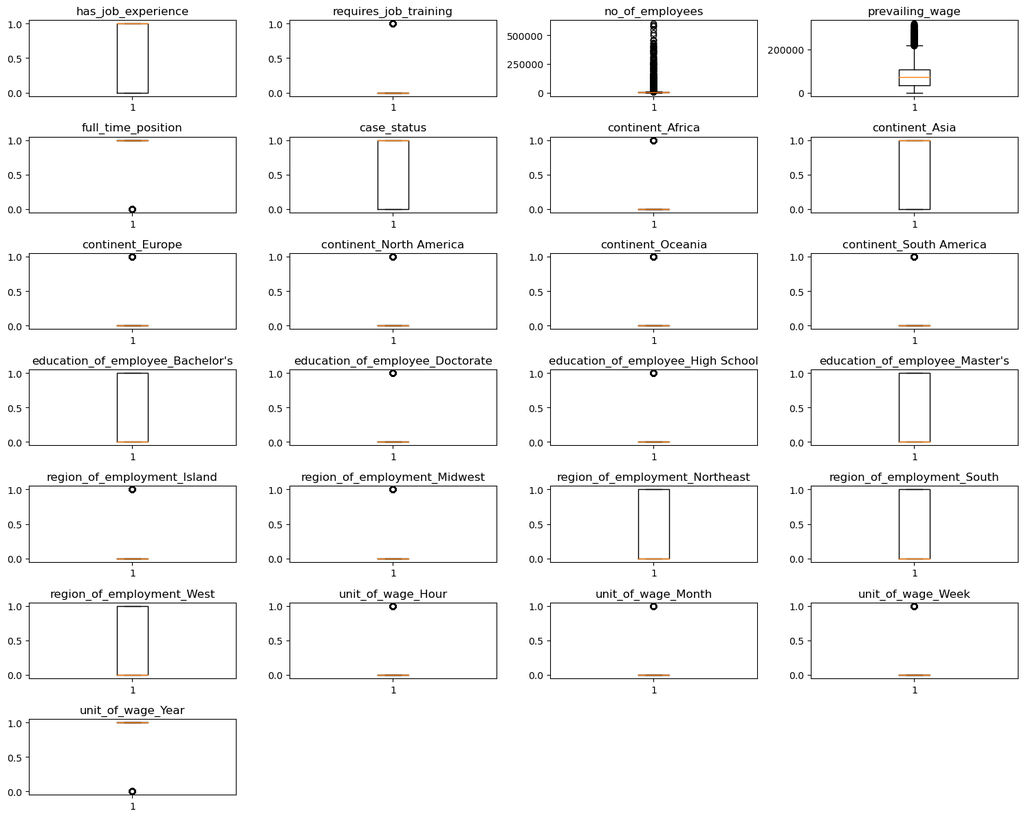

```python
# Detección de valores extremos usando boxplot
numeric_columns = data.select_dtypes(include=np.number).columns.tolist()


plt.figure(figsize=(15, 12))

for i, variable in enumerate(numeric_columns):
    plt.subplot(7, 4, i + 1)
    plt.boxplot(data[variable], whis=1.5)
    plt.tight_layout()
    plt.title(variable)

plt.show()
```

- No se hará tratamiento de valores extremos.

## Creación de modelos de bagging y boosting

Criterio de evaluación del modelo

El modelo puede hacer predicciones incorrectas como:

Facilitar el proceso de aprobación de visas. Recomendar un perfil adecuado para los solicitantes a quienes se les debe certificar o denegar la visa en función de los factores que influyen significativamente en el estado del caso.

```
a) Predecir que un perfil es adecuado para certificar la visa, pero realmente el perfil debió ser denegado.
b) Predecir que un perfil  deba ser denegado, pero realmente debió ser un perfil certificado.
```

¿Qué caso es más importante?

```
Ambos casos son importantes.
En el caso a) se si se concede una visa a un perfil no apto, el gobierno estará perdiendo la oportunidad de que un mejor candidado ó un ciudadano acceda y contribuya en este puesto.
En el caso b) si se niega la visa a un perfil que debió ser certificado, el gobierno estará perdiendo un potencial empleado o capital humano valioso que aporte a la economía de USA.
```

¿Cómo reducir esta pérdida?

Se requiere reducir tanto los falsos positivos (caso a), como los falsos negativos (caso b)

- `f1_score` debe maximizarse ya que cuanto mayor sea el f1_score, mayores serán las posibilidades de reducir tanto los falsos negativos como los falsos positivos e identificar ambas clases correctamente*

### CONSTRUCCIÓN DE MODELOS

### Preparación de datos para la construcción de modelos

```python
# Identificaicón de las varianles dependiente e independientes:
X = data.drop("case_status" , axis=1)
y = data.pop("case_status")
print(X.head())
print(y.head())
```

```
   has_job_experience  requires_job_training  no_of_employees  \
0                   0                      0            14513
1                   1                      0             2412
2                   0                      1            44444
3                   0                      0               98
4                   1                      0             1082

   prevailing_wage  full_time_position  continent_Africa  continent_Asia  \
0          592.203                   1                 0               1
1        83425.650                   1                 0               1
2       122996.860                   1                 0               1
3        83434.030                   1                 0               1
4       149907.390                   1                 1               0

   continent_Europe  continent_North America  continent_Oceania  ...  \
```

[output cut: 41 more lines]

### Dividir los datos en conjuntos de entrenamiento y prueba

```python
# División de la data en el set de entrenamiento-prueba 70:30 ratio:
X_train, X_test, y_train, y_test =train_test_split(X, y, test_size=0.3, random_state=1,stratify=y)
print(X_train.shape, X_test.shape)
```

```
(17836, 24) (7644, 24)
```

```python
print (f"Se tiene", X_train.shape[0],"observaciones en el conjunto de entrenamiento y ", X_test.shape[0],"observaciones en el conjunto de prueba.")
```

```
Se tiene 17836 observaciones en el conjunto de entrenamiento y  7644 observaciones en el conjunto de prueba.
```

```python
#Verificación de el balance de la data
y.value_counts(1)
```

```
1   0.668
0   0.332
Name: case_status, dtype: float64
```

```python
#Verificación de el balance de la data en los datos de prueba
y_test.value_counts(1)
```

```
1   0.668
0   0.332
Name: case_status, dtype: float64
```

**Definamos la función para proporcionar puntajes métricos (fiabilidad, sensibilidad y precisión) en el conjunto de pruebas y entrenamiento y una función para mostrar la matriz de confusión , de forma que se agilice la evaluación de los modelos.**

```python
# defining a function to compute different metrics to check performance of a classification model built using sklearn
def model_performance_classification_sklearn(model, predictors, target):
    """
    Function to compute different metrics to check classification model performance

    model: classifier
    predictors: independent variables
    target: dependent variable
    """

    # predicting using the independent variables
    pred = model.predict(predictors)

    acc = accuracy_score(target, pred)  # to compute Accuracy
    recall = recall_score(target, pred)  # to compute Recall
    precision = precision_score(target, pred)  # to compute Precision
    f1 = f1_score(target, pred)  # to compute F1-score

    # creating a dataframe of metrics
    df_perf = pd.DataFrame(
        {
            "Accuracy": acc,
            "Recall": recall,
            "Precision": precision,
            "F1": f1,
        },
        index=[0],
    )

    return df_perf
```

```python
def confusion_matrix_sklearn(model, predictors, target):
    """
    To plot the confusion_matrix with percentages

    model: classifier
    predictors: independent variables
    target: dependent variable
    """
    y_pred = model.predict(predictors)
    cm = confusion_matrix(target, y_pred)
    labels = np.asarray(
        [
            ["{0:0.0f}".format(item) + "\n{0:.2%}".format(item / cm.flatten().sum())]
            for item in cm.flatten()
        ]
    ).reshape(2, 2)

    plt.figure(figsize=(6, 4))
    sns.heatmap(cm, annot=labels, fmt="")
    plt.ylabel("True label")
    plt.xlabel("Predicted label")
```

### CONSTRUCCIÓN DE MODELOS

### Modelo de árbol de decisión

Utilizaremos la función DecisionTreeClassifier para construir nuestro modelo y configuraremos los criterios de división en 'gini' como predeterminados.

Cuando la clase A tiene una frecuencia del 10 % y la clase B tiene una frecuencia del 90 %, la clase B se convertirá en la clase dominante, lo que resultará en que el árbol de decisiones esté sesgado hacia las clases dominantes.

Para abordar el desbalance de datos, ajustaremos los pesos de clase utilizando un diccionario, {0:0.67, 1:0.33}, en el modelo. Esto permitirá que el árbol de decisión otorgue más importancia a la clase 0.

El parámetro class_weight es un hiperparámetro del clasificador de árbol de decisión que controla el peso asignado a cada clase durante el proceso de entrenamiento.

```python
# Modelo árbol de desición con balanceo artificial
dtree = DecisionTreeClassifier(criterion='gini',class_weight={0:0.67,1:0.33},random_state=1)
```

```python
dtree.fit(X_train, y_train)
```

```
DecisionTreeClassifier(class_weight={0: 0.67, 1: 0.33}, random_state=1)
```

```python
confusion_matrix_sklearn(dtree, X_train, y_train)
```

[output not shown]

**Matriz de confusión -**

```python
dtree_model_train_perf=model_performance_classification_sklearn(dtree, X_train, y_train)
print("Training performance \n",dtree_model_train_perf)
```

```
Training performance
    Accuracy  Recall  Precision    F1
0     1.000   1.000      1.000 1.000
```

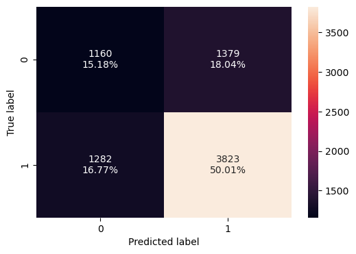

```python
confusion_matrix_sklearn(dtree, X_test, y_test)
```

```python
dtree_model_test_perf=model_performance_classification_sklearn(dtree, X_test, y_test)
print("Testing performance \n",dtree_model_test_perf)
```

```
Testing performance
    Accuracy  Recall  Precision    F1
0     0.652   0.749      0.735 0.742
```

##### Arbol de decisión

- El árbol de decisión funciona bien con los datos de entrenamiento, pero no puede generalizar bien con los datos de prueba relacionados con ninguno de los evaluadores de rendimiento. Esto implica que el modelo está sobreajustado, el f1_score cae de 1 a 0.74

### Clasificador de bagging

```python
#Vamos a usar el standar con estimador base arbol de desición
bagging = BaggingClassifier(random_state=1)
bagging.fit(X_train,y_train)
```

```
BaggingClassifier(random_state=1)
```

##### Rendimiento en el set de entrenamiento

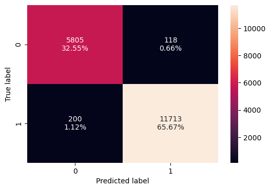

```python
confusion_matrix_sklearn(bagging, X_train, y_train)
```

```python
bagging_model_train_perf=model_performance_classification_sklearn(bagging, X_train, y_train)
print("Training performance \n",bagging_model_train_perf)
```

```
Training performance
    Accuracy  Recall  Precision    F1
0     0.982   0.983      0.990 0.987
```

##### Rendimiento en el set de prueba

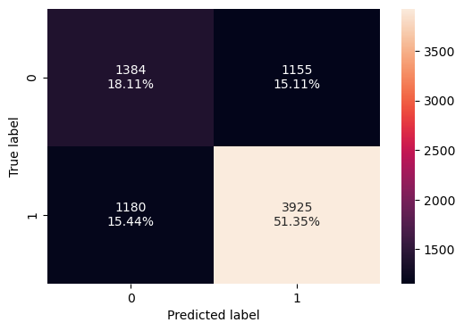

```python
confusion_matrix_sklearn(bagging, X_test, y_test)
```

```python
bagging_model_test_perf=model_performance_classification_sklearn(bagging, X_test, y_test)
print("Testing performance \n",bagging_model_test_perf)
```

```
Testing performance
    Accuracy  Recall  Precision    F1
0     0.695   0.769      0.773 0.771
```

##### Bagging_model

- El árbol de decisión funciona bien con los datos de entrenamiento, pero no puede generalizar bien con los datos de prueba relacionados con ninguno de los evaluadores de rendimiento. Esto implica que el modelo está sobreajustado, el f1_score cae de 0.98 a 0.77
- El estimador base y por defecto de este modelo no nos proporciona el modelo requerido.

### **Clasificador de Bagging con árbol de decisión ponderado**

```python
# Ajustamos el modelo por defecto  con algunos parámetros según la iformación que conocemos
bagging_wt = BaggingClassifier(base_estimator=DecisionTreeClassifier(criterion='gini',class_weight={0:0.67,1:0.33},random_state=1),random_state=1)
bagging_wt.fit(X_train,y_train)
```

```
BaggingClassifier(base_estimator=DecisionTreeClassifier(class_weight={0: 0.67,
                                                                      1: 0.33},
                                                        random_state=1),
                  random_state=1)
```

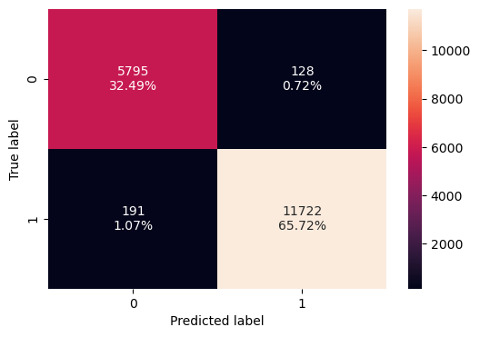

```python
confusion_matrix_sklearn(bagging_wt,X_train,y_train)
```

```python
bagging_wt_model_train_perf=model_performance_classification_sklearn(bagging_wt,X_train,y_train)
print("Training performance \n",bagging_wt_model_train_perf)
```

```
Training performance
    Accuracy  Recall  Precision    F1
0     0.982   0.984      0.989 0.987
```

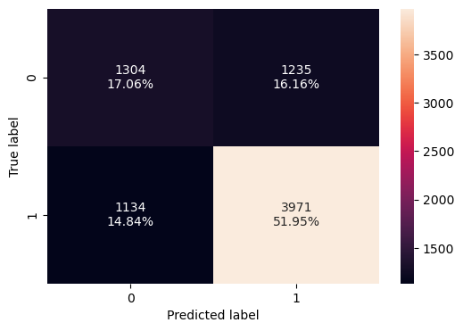

```python
confusion_matrix_sklearn(bagging_wt,X_test,y_test)
```

```python
bagging_wt_model_test_perf=model_performance_classification_sklearn(bagging_wt, X_test, y_test)
print("Testing performance \n",bagging_wt_model_test_perf)
```

```
Testing performance
    Accuracy  Recall  Precision    F1
0     0.690   0.778      0.763 0.770
```

##### Bagging_model con un árbol de decisión ponderado

- De igual forma en este modelo, el clasificador de **bagging con un árbol de decisión ponderado** brinda funciona bien con los datos de entrenamiento, pero no puede generalizar bien con los datos de prueba relacionados con ninguno de los evaluadores de rendimiento.
- Con la técnica empleada, no se logró controlar el sobreajuste, el f1_score cae de 0.99 a 0.77

### Random Forest

```python
#Vamos a probar con ramdon forest en vez de sklearn
rf = RandomForestClassifier(random_state=1)
rf.fit(X_train,y_train)
```

```
RandomForestClassifier(random_state=1)
```

```python
confusion_matrix_sklearn(rf,X_train,y_train)
```

[output not shown]

```python
rf_model_train_perf=model_performance_classification_sklearn(rf,X_train,y_train)
print("Training performance \n",rf_model_train_perf)
```

```
Training performance
    Accuracy  Recall  Precision    F1
0     1.000   1.000      1.000 1.000
```

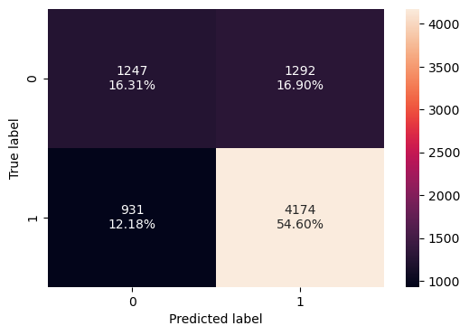

```python
confusion_matrix_sklearn(rf,X_test,y_test)
```

```python
rf_model_test_perf=model_performance_classification_sklearn(rf,X_test,y_test)
print("Testing performance \n",rf_model_test_perf)
```

```
Testing performance
    Accuracy  Recall  Precision    F1
0     0.709   0.818      0.764 0.790
```

- **Random Forest** se ha desempeñado bien en los datos de entrenamiento, pero no puede generalizar los datos de la prueba en términos de ninguna métrica de rendimiento.
- f1_score tuvo una caída del 20% en todas la métricas lo cual indica que el modelo no es el adecuado aún, y sigue sobreajustado.

### **Random Forest con pesos de clase**

```python
# Random Forest balanceado de forma artificial
rf_wt = RandomForestClassifier(class_weight={0:0.67,1:0.33}, random_state=1)
rf_wt.fit(X_train,y_train)
```

```
RandomForestClassifier(class_weight={0: 0.67, 1: 0.33}, random_state=1)
```

```python
confusion_matrix_sklearn(rf_wt, X_train,y_train)
```

[output not shown]

```python
rf_wt_model_train_perf=model_performance_classification_sklearn(rf_wt, X_train,y_train)
print("Training performance \n",rf_wt_model_train_perf)
```

```
Training performance
    Accuracy  Recall  Precision    F1
0     1.000   1.000      1.000 1.000
```

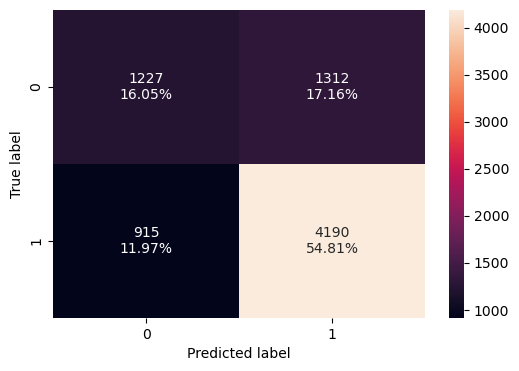

```python
confusion_matrix_sklearn(rf_wt, X_test,y_test)
```

```python
rf_wt_model_test_perf=model_performance_classification_sklearn(rf_wt, X_test,y_test)
print("Testing performance \n",rf_wt_model_test_perf)
```

```
Testing performance
    Accuracy  Recall  Precision    F1
0     0.709   0.821      0.762 0.790
```

Respecto al modelo **Random Forest con pesos de clase**:

- No hay mucha mejora en las métricas del bosque aleatorio ponderado en comparación con el bosque aleatorio no ponderado.
- El modelo aún mantiene sobreajuste y no es aún el indicado

## Tuning Models

### Uso de GridSearch para el modelo de ajuste de hiperparámetros

- Ajustar los hiperparámetros puede ser complicado debido a la falta de una fórmula directa para determinar cómo un cambio en el valor de un hiperparámetro afectará la pérdida de un modelo. Por lo tanto, a menudo se recurre a la experimentación.
- La búsqueda en cuadrícula es un enfoque utilizado para calcular los valores óptimos de los hiperparámetros de un modelo.
- Este método implica una exploración exhaustiva de los valores posibles de ciertos parámetros del modelo.
- Durante la búsqueda en cuadrícula, los parámetros del modelo se ajustan utilizando validación cruzada a lo largo de una cuadrícula de valores de hiperparámetros predefinidos.

### Árbol de decisiones con ajuste de hiperparámetros

```python
%%time
# Choose the type of classifier.
dtree_estimator = DecisionTreeClassifier(class_weight={0:0.67,1:0.33},random_state=1)

# Grid of parameters to choose from. Experimento iterativo
parameters = {'max_depth': np.arange(1,10), # 9 modelos-#np.arange(2,30) muy alto por el momento,  #PROFUNDAD 10, MAXIMO
              'min_samples_leaf': [3,5, 7, 11,15, 19],# 9x5=45
              'max_leaf_nodes' : [2, 10, 50, 100, 250], #45*5=225  # de nodos máximo es 2 a la 10
              'min_impurity_decrease': [0.0001,0.0002,0.01,0.001] #225*4= 900 modelos entrenando, con este ajuste de hiperparametros
             }

# Type of scoring used to compare parameter combinations
scorer = metrics.make_scorer(metrics.f1_score)

# Run the grid search
grid_obj = GridSearchCV(dtree_estimator, parameters, scoring=scorer)
grid_obj = grid_obj.fit(X_train, y_train)

# Set the clf to the best combination of parameters
dtree_estimator = grid_obj.best_estimator_

# Fit the best algorithm to the data.
dtree_estimator.fit(X_train, y_train)
```

```
CPU times: total: 2min 14s
Wall time: 2min 41s
```

```
DecisionTreeClassifier(class_weight={0: 0.67, 1: 0.33}, max_depth=1,
                       max_leaf_nodes=2, min_impurity_decrease=0.0001,
                       min_samples_leaf=3, random_state=1)
```

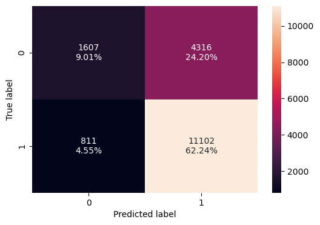

```python
confusion_matrix_sklearn(dtree_estimator, X_train,y_train)
```

```python
dtree_estimator_model_train_perf=model_performance_classification_sklearn(dtree_estimator, X_train,y_train)
print("Training performance \n",dtree_estimator_model_train_perf)
```

```
Training performance
    Accuracy  Recall  Precision    F1
0     0.713   0.932      0.720 0.812
```

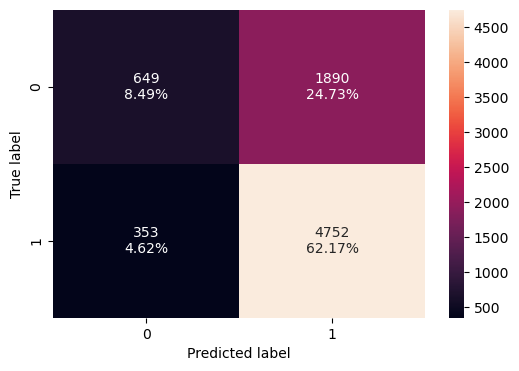

```python
confusion_matrix_sklearn(dtree_estimator, X_test,y_test)
```

```python
dtree_estimator_model_test_perf=model_performance_classification_sklearn(dtree_estimator, X_test, y_test)
print("Testing performance \n",dtree_estimator_model_test_perf)
```

```
Testing performance
    Accuracy  Recall  Precision    F1
0     0.707   0.931      0.715 0.809
```

Respecto al modelo **Árbol de decisiones de ajuste**

- Se ha reducido el sobreajuste en el árbol de decisiones. Los datos de entrenamiento generalizan en los datos de prueba.
- El modelo es muy bueno en Recall (0.93), en cuanto a f1_score, que es nuestra métrica de interés, este se mantiene en 0.81.
- Este modelo indica:

Recall (Sensibilidad): Un valor de recall de 0.93 indica que el modelo es muy bueno para identificar las solicitudes de visa que realmente deberían ser aceptadas. Siendo que, de todas las solicitudes que deberían ser aprobadas, el modelo identifica correctamente el 93% de ellas.

F1_score: El F1_score es una métrica que combina tanto la precisión como el recall en una sola puntuación. Un F1_score de 0.80 sugiere que el modelo tiene un buen equilibrio entre la precisión y el recall en la clasificación de las solicitudes de visa.

De forma que el modelo no solo es bueno para identificar las solicitudes que deben ser aceptadas (alto recall), sino que también es preciso en su clasificación en general.

- El mejor modelo escogió un arbol pequeño de profundidad 1 con 2 nodos, un árbol muy sencillo.

### Clasificador Tuning Bagging

```python
%%time
#grid search for bagging classifier
cl1 = DecisionTreeClassifier(class_weight={0:0.14,1:0.86},random_state=1)# mantengo data balanceada
param_grid = {'base_estimator':[cl1], # usa arbol de desición como estimador
              'n_estimators':[25,50,100,150,200, 500], # 1000 arboles!
              'max_features': [0.7,0.8,0.9,1]# ajusta bagging a bosque aleatorio-agrega algo de aleatoriedad
             }

grid = GridSearchCV(BaggingClassifier(random_state=1,bootstrap=True), param_grid=param_grid, scoring = scorer, cv = 5)
grid.fit(X_train, y_train)

## getting the best estimator
bagging_estimator  = grid.best_estimator_
bagging_estimator.fit(X_train,y_train)
```

```
CPU times: total: 13min 7s
Wall time: 15min 28s
```

```
BaggingClassifier(base_estimator=DecisionTreeClassifier(class_weight={0: 0.14,
                                                                      1: 0.86},
                                                        random_state=1),
                  max_features=0.7, n_estimators=200, random_state=1)
```

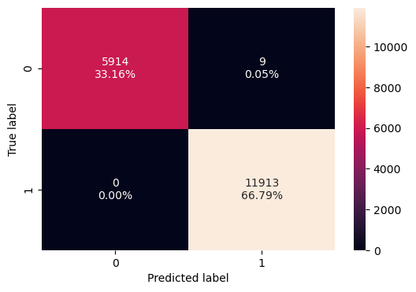

```python
confusion_matrix_sklearn(bagging_estimator, X_train,y_train)
```

```python
bagging_estimator_model_train_perf=model_performance_classification_sklearn(bagging_estimator, X_train,y_train)
print("Training performance \n",bagging_estimator_model_train_perf)
```

```
Training performance
    Accuracy  Recall  Precision    F1
0     0.999   1.000      0.999 1.000
```

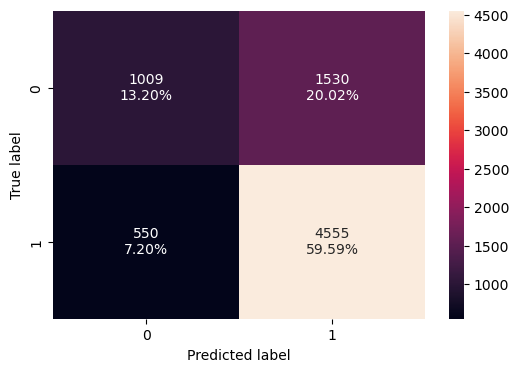

```python
confusion_matrix_sklearn(bagging_estimator, X_test,y_test)
```

```python
bagging_estimator_model_test_perf=model_performance_classification_sklearn(bagging_estimator, X_test, y_test)
print("Testing performance \n",bagging_estimator_model_test_perf)
```

```
Testing performance
    Accuracy  Recall  Precision    F1
0     0.728   0.892      0.749 0.814
```

### Ajuste de hiperparámetros Random Forest

```python
%%time
# Choose the type of classifier.
rf_estimator = RandomForestClassifier(random_state=1)

# Grid of parameters to choose from
parameters = {
        "n_estimators": [110,250,500], #100 por default
        "min_samples_leaf": [5, 7, 11,15, 19],  #igual al arbol de arriba
        "max_features": [0.7,0.9,'log2','sqrt'], # determinar el total de features ó columnas raíz cuadrada o log2
        "max_samples": [0.7, 0.9, None],
        'max_depth': [1,3,5] # vimos en el modelo anterior , nos sirven arboles pequeños
}

# Run the grid search
grid_obj = GridSearchCV(rf_estimator, parameters, scoring= scorer,cv=5, n_jobs=-1)
grid_obj = grid_obj.fit(X_train, y_train)

# Set the clf to the best combination of parameters
rf_estimator = grid_obj.best_estimator_

# Fit the best algorithm to the data.
rf_estimator.fit(X_train, y_train)
```

```
CPU times: total: 21.6 s
Wall time: 11min 8s
```

```
RandomForestClassifier(max_depth=5, max_features=0.7, min_samples_leaf=19,
                       n_estimators=250, random_state=1)
```

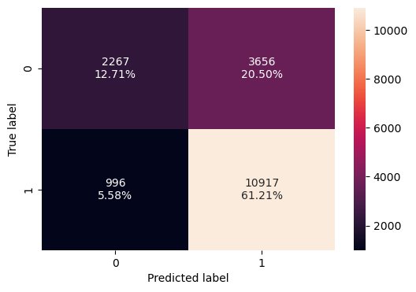

```python
confusion_matrix_sklearn(rf_estimator, X_train,y_train)
```

```python
rf_estimator_model_train_perf=model_performance_classification_sklearn(rf_estimator, X_train,y_train)
print("Training performance \n",rf_estimator_model_train_perf)
```

```
Training performance
    Accuracy  Recall  Precision    F1
0     0.739   0.916      0.749 0.824
```

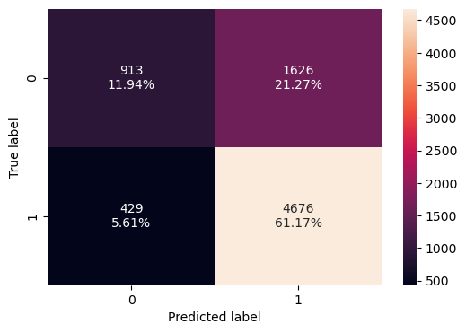

```python
confusion_matrix_sklearn(rf_estimator, X_test,y_test)
```

```python
rf_estimator_model_test_perf=model_performance_classification_sklearn(rf_estimator, X_test, y_test)
print("Testing performance \n",rf_estimator_model_test_perf)
```

```
Testing performance
    Accuracy  Recall  Precision    F1
0     0.731   0.916      0.742 0.820
```

### Comparando todos los modelos (Bagging-Random Forest)

```python
# Comparación del rendimiento en los datos de entrenamiento
models_train_comp_df = pd.concat(
    [dtree_model_train_perf.T,bagging_model_train_perf.T, bagging_wt_model_train_perf.T,rf_model_train_perf.T,
    rf_wt_model_train_perf.T,dtree_estimator_model_train_perf.T, bagging_estimator_model_train_perf.T,
     rf_estimator_model_train_perf.T],
    axis=1,
)
models_train_comp_df.columns = [
    "Decision Tree",
    "Bagging Classifier",
    "Weighted Bagging Classifier",
    "Random Forest Classifier",
    "Weighted Random Forest Classifier",
    "Decision Tree Estimator",
    "Bagging Estimator",
    "Random Forest Estimator"]
print("Comparación del rendimiento en el set de  entrenamiento:")
models_train_comp_df
```

```
Comparación del rendimiento en el set de  entrenamiento:
```

|  | Decision Tree | Bagging Classifier | Weighted Bagging Classifier | Random Forest Classifier | Weighted Random Forest Classifier | Decision Tree Estimator | Bagging Estimator | Random Forest Estimator |
| --- | --- | --- | --- | --- | --- | --- | --- | --- |
| Accuracy | 1.000 | 0.982 | 0.982 | 1.000 | 1.000 | 0.713 | 0.999 | 0.739 |
| Recall | 1.000 | 0.983 | 0.984 | 1.000 | 1.000 | 0.932 | 1.000 | 0.916 |
| Precision | 1.000 | 0.990 | 0.989 | 1.000 | 1.000 | 0.720 | 0.999 | 0.749 |
| F1 | 1.000 | 0.987 | 0.987 | 1.000 | 1.000 | 0.812 | 1.000 | 0.824 |

```python
# Comparación del rendimiento en los datos de prueba

models_test_comp_df = pd.concat(
    [dtree_model_test_perf.T,bagging_model_test_perf.T, bagging_wt_model_test_perf.T,rf_model_test_perf.T,
    rf_wt_model_test_perf.T,dtree_estimator_model_test_perf.T, bagging_estimator_model_test_perf.T,
     rf_estimator_model_test_perf.T],
    axis=1,
)
models_test_comp_df.columns = [
    "Decision Tree",
    "Bagging Classifier",
    "Weighted Bagging Classifier",
    "Random Forest Classifier",
    "Weighted Random Forest Classifier",
    "Decision Tree Estimator",
    "Bagging Estimator",
    "Random Forest Estimator"]
print("Comparación del rendimiento en el set de prueba:")
models_test_comp_df
```

```
Comparación del rendimiento en el set de prueba:
```

|  | Decision Tree | Bagging Classifier | Weighted Bagging Classifier | Random Forest Classifier | Weighted Random Forest Classifier | Decision Tree Estimator | Bagging Estimator | Random Forest Estimator |
| --- | --- | --- | --- | --- | --- | --- | --- | --- |
| Accuracy | 0.652 | 0.695 | 0.690 | 0.709 | 0.709 | 0.707 | 0.728 | 0.731 |
| Recall | 0.749 | 0.769 | 0.778 | 0.818 | 0.821 | 0.931 | 0.892 | 0.916 |
| Precision | 0.735 | 0.773 | 0.763 | 0.764 | 0.762 | 0.715 | 0.749 | 0.742 |
| F1 | 0.742 | 0.771 | 0.770 | 0.790 | 0.790 | 0.809 | 0.814 | 0.820 |

##### Observaciones/ Comparación de modelos

- El árbol de decisiones demostró sobreajuste y no generalizó bien el conjunto de entrenamiento y prueba.
- El árbol árbol de decisiones con ajuste de hiperparámetros (Decision Tree Estimator) generalizó bien el conjunto de entrenamiento y prueba. A pesar que se tiene un buen f1_score (0.81) Este modelo es mejor en cuanto a sensibilidad y la detección de casos positivos.
- El clasificador Random Forest demostró sobreajuste y no generalizó bien el conjunto de entrenamiento y prueba.
- El clasificador Random Forest con pesos de clase tampoco generalizó bien el conjunto de entrenamiento y prueba, mostrando sobreajuste.
- El clasificador Random Forest ajustado con hiper parámetros, generalizó en los datos de entrenamiento y prueba, siendo un modelo con un f1_score (0.82) bueno, sin embargo este modelo por su alto recall (0.92) indica que el modelo tiende a identificar la mayoría de los casos positivos o verdaderos positivos en el conjunto de datos, indica que hay menos falsos negativos, y aunque un alto Recall es beneficioso para identificar positivos verdaderos, también puede resultar en más falsos positivos.
- El clasificador bagging (Bagging Classifier) sobreajustó los datos antes y después del ajuste (Baggin Estimator). De forma que en ese caso no hubo mejora con el uso de los hiperparámetros.
- Es importante mencionar, que Random Forest ajustado, los resultados finales dependen de los parámetros utilizados/verificados mediante GridSearchCV, por lo que puede haber parámetros aún mejores que pueden dar como resultado un mejor rendimiento.
- Aunque un alto Recall es beneficioso para identificar positivos verdaderos, también puede resultar en más falsos positivos. Es decir, el modelo puede clasificar algunos casos negativos como positivos. Por lo tanto, es importante equilibrar el Recall y buscar un mejor F1-score.

##### Importancia de la característica de Random Forest

```python
### Importancia de las característica acorde a modelo de árbol de desición
###( La importancia de una característica se calcula como la reducción total
###(normalizada) del criterio proporcionada por esa característica.
### También se conoce como la importancia de Gini.

print (pd.DataFrame(dtree_estimator.feature_importances_, columns = ["Imp"],
                    index = X_train.columns).sort_values(by = 'Imp', ascending = False))
```

```
                                    Imp
education_of_employee_High School 1.000
has_job_experience                0.000
requires_job_training             0.000
unit_of_wage_Week                 0.000
unit_of_wage_Month                0.000
unit_of_wage_Hour                 0.000
region_of_employment_West         0.000
region_of_employment_South        0.000
region_of_employment_Northeast    0.000
region_of_employment_Midwest      0.000
region_of_employment_Island       0.000
education_of_employee_Master's    0.000
education_of_employee_Doctorate   0.000
education_of_employee_Bachelor's  0.000
continent_South America           0.000
continent_Oceania                 0.000
continent_North America           0.000
continent_Europe                  0.000
continent_Asia                    0.000
continent_Africa                  0.000
full_time_position                0.000
prevailing_wage                   0.000
no_of_employees                   0.000
unit_of_wage_Year                 0.000
```

```python
feature_names = X_train.columns
```

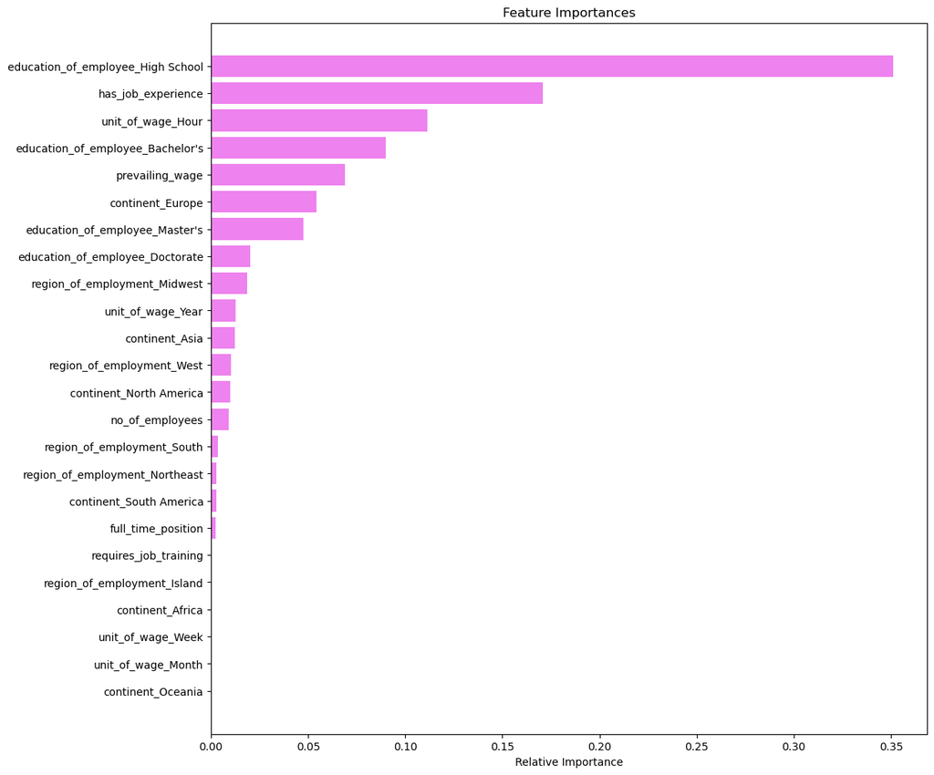

```python
#Visualización de las caracteristicas más importantes para Random Forest-ajustado

importances = rf_estimator.feature_importances_
indices = np.argsort(importances)

plt.figure(figsize=(12,12))
plt.title('Feature Importances')
plt.barh(range(len(indices)), importances[indices], color='violet', align='center')
plt.yticks(range(len(indices)), [feature_names[i] for i in indices])
plt.xlabel('Relative Importance')
plt.show()
```

- Para el caso de bagging, los modelos con mejor comportamiento, en donde se da generalización de los datos de entrenamiento y prueba, y se tiene el menor sobreajuste corresponde a los modelos de árbol de decisión ajustado y Random Forest ajustado.
- Para el modelo de árboles de decisión ajustado: dtree_estimator, las carácteristicas de mayor interés son ( en orden de mayor a menor):

class_weight={0: 0.67, 1: 0.33}: Cuando se asignó pesos diferentes a las clases para abordar el desequilibrio de clases en los datos, la clase 0 (visa denegada) tiene un peso mayor que la clase 1 (visa aceptada), lo que indica que el modelo dará más importancia a la predicción precisa de la clase 0.

Es importante mencionar, que el modelo escogió max_depth=1: La profundidad máxima del árbol de decisión es 1. Esto significa que el árbol solo puede tener una división, lo que lo convierte en un árbol de decisión extremadamente simple. Esta restricción puede ser una de las razones por las que una sola característica, en este caso, "education_of_employee_High School", puede tener una importancia muy alta, ya que el árbol no tiene la profundidad para explorar relaciones más complejas entre las características.

- Para el modelo de Random Forest ajustado: dtree_estimator, las carácteristicas de mayor interés son ( en orden de mayor a menor):

Nivel educativo del empleado: High School Si el solicitante tiene ó no experiencia laboral Unidad de salario prevaleciente: Horas Nivel educativo del empleado: Bachiller Salario prevaleciente

##### Conclusiones

##### ¿Mejorará el rendimiento del modelo el ajuste de los hiperparámetros?

Mejorar el rendimiento del modelo a través del ajuste de hiperparámetros es una práctica común en el aprendizaje automático.

El ajuste de hiperparámetros puede tener un impacto significativo en la capacidad de un modelo para generalizar y mejorar su rendimiento. En resumen, ajustar los hiperparámetros puede mejorar el rendimiento de predicción de visas, especialmente para mejorar un sobreajuste o un rendimiento insatisfactorio en el conjunto de prueba.

En nuestro caso, como se mencionó, alguno modelos no lograron generalizar ni antes ni después de ajustarlos como el caso de Bagging Classifier, Weighted Bagging Classifier.

En nuestro caso el modelo que mejor rendimiento tuvo y menor sobreajuste gracias a la calibración de hiperpáretros fué el modelo Random Forest Classifier.

## Información práctica y recomendaciones

"En este estudio, desarrollamos y evaluamos varios modelos de predicción de visas utilizando técnicas de bagging, incluido Random Forest. Nuestro objetivo era predecir si una solicitud de visa sería aceptada (1) o denegada (0). Utilizamos métricas de evaluación como precisión, recall y F1-score para evaluar el rendimiento de los modelos.

Observamos que nuestros modelos entrenados mostraron un rendimiento excepcional en el conjunto de entrenamiento, con puntajes de precisión y recall cercanos al 100%. Sin embargo, al evaluar los modelos en el conjunto de prueba, vimos que el rendimiento se redujo en comparación con el conjunto de entrenamiento, lo que sugiere la posibilidad de sobreajuste.

Del Eda realizado y la manipulación de los datos en conjunto con estos resultados se puede concluir:

a) como el nivel educativo del empleado (especialmente High School y Bachiller)

Un nivel educativo mayor, tiende a ayudar a conceder una visa, sin embargo, hay casos donde niveles de estudios como como el nivel educativo del empleado (High School) lograban una certificación, sobretodo si el salario prevaleciente era alto, para la zona escogida y el empleado tiene experiencia laboral. En general la mayoria de solicitudes con High School como nivel de estudios son rechazadas.

b) Si el solicitante tiene ó no experiencia laboral, los candidatos con experiencia laboral tienen más posibilidades de aprobar una solicitud.

c) Unidad de salario prevaleciente: Horas, podría disminuir el peso de certificar la visa.

d) Nivel educativo del empleado: Bachiller - En el caso de la educación superior como "Bachelor´s", ó "Masters" tienen mayor peso para certificar la visa.

e) Salario prevaleciente: A mayores salarios prevalecientes sobre las 70 000 a 75 000 unidades en promedio, se mejoran las posibilidades de certificar la visa, esto según la region y el nivel de estudios.

Se recomienda continuar con el ajuste de los hiperparámetros, realiza una búsqueda sistemática de hiperparámetros, utiliza validación cruzada y considera técnicas de regularización y balanceo de clases según sea necesario para optimizar el F1-score y lograr un modelo más efectivo.

##### ***

## Boosting: construcción de modelos y ajuste de hiperparámetros

- Se construirán tres modelos de conjunto en este contexto: un clasificador AdaBoost, un clasificador de aumento de gradiente y un clasificador XGBoost.
- En primer lugar, construiremos estos modelos utilizando los valores predeterminados de sus parámetros y luego procederemos a ajustar los hiperparámetros para mejorar el rendimiento de cada modelo.
- Mediremos el rendimiento de estos modelos utilizando tres métricas: precisión, sensibilidad (recall) y el puntaje F1. Sin embargo, nuestra principal métrica de interés en este caso es el puntaje F1.
- El puntaje F1 combina la precisión y la sensibilidad en una sola métrica, lo que nos permite evaluar el equilibrio entre la capacidad de nuestro modelo para predecir correctamente las dos clases.

### Clasificador de AdaBoost

El modelo AdaBoost, que significa "Adaptative Boosting" o "Aumento Adaptativo", es un algoritmo de aprendizaje automático utilizado en clasificación y regresión. Se enmarca dentro de la categoría de algoritmos de conjunto o ensemble, lo que significa que combina múltiples modelos de aprendizaje (generalmente débiles o simples) para formar un modelo más robusto y preciso.

La idea principal detrás de AdaBoost es dar más peso a los ejemplos de entrenamiento que son difíciles de clasificar y menos peso a los ejemplos que son fáciles de clasificar. Esto se logra ajustando iterativamente el peso de los ejemplos en el conjunto de entrenamiento para que los clasificadores subsiguientes se centren en los ejemplos mal clasificados por los clasificadores anteriores.

El resultado es un modelo de conjunto que generalmente tiene un buen rendimiento en la clasificación, Una de las ventajas clave de AdaBoost es su capacidad para manejar datos desequilibrados y mejorar la precisión de la clasificación de la clase minoritaria. Sin embargo, puede ser sensible al ruido en los datos y al sobreajuste si el conjunto de entrenamiento es ruidoso o muy pequeño.

```python
abclassifier = AdaBoostClassifier(random_state=1)
abclassifier.fit(X_train,y_train)
```

```
AdaBoostClassifier(random_state=1)
```

##### Revisión del rendimiento en el conjunto de entrenamiento

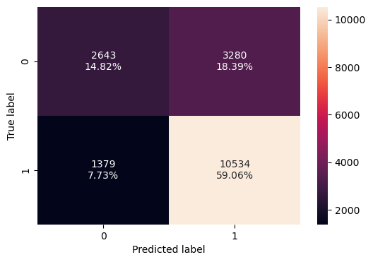

```python
confusion_matrix_sklearn(abclassifier, X_train,y_train)
```

```python
abclassifier_model_train_perf=model_performance_classification_sklearn(abclassifier, X_train,y_train)
print("Training performance \n",abclassifier_model_train_perf)
```

```
Training performance
    Accuracy  Recall  Precision    F1
0     0.739   0.884      0.763 0.819
```

##### Revisión del rendimiento en el conjunto de prueba

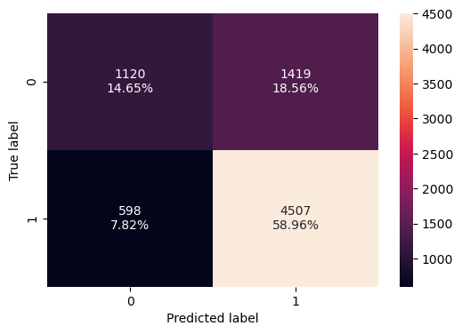

```python
confusion_matrix_sklearn(abclassifier, X_test,y_test)
```

```python
abclassifier_model_test_perf=model_performance_classification_sklearn(abclassifier, X_test, y_test)
print("Testing performance \n",abclassifier_model_test_perf)
```

```
Testing performance
    Accuracy  Recall  Precision    F1
0     0.736   0.883      0.761 0.817
```

###### Observaciones clasificador de AdaBoost

- El modelo AdaBost ha demostrado generalizar bien en los datos de entrenamiento y prueba.
- El modelo es proncipalmente fuerte en Recall (0.88), pero también muestra cierta eficiencia en Precisión ( 0.76)
- El f1_score es de 0.816, lo que implica un modelo aceptable.

### Clasificador de aumento de gradiente

```python
gbc = GradientBoostingClassifier(random_state=1)
gbc.fit(X_train,y_train)
```

```
GradientBoostingClassifier(random_state=1)
```

##### Revisión del rendimiento en el conjunto de entrenamiento

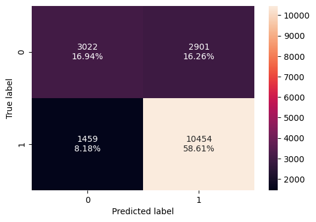

```python
confusion_matrix_sklearn(gbc, X_train,y_train)
```

```python
gbc_model_train_perf=model_performance_classification_sklearn(gbc, X_train,y_train)
print("Training performance \n",gbc_model_train_perf)
```

```
Training performance
    Accuracy  Recall  Precision    F1
0     0.756   0.878      0.783 0.827
```

##### Revisión del rendimiento en el conjunto de prueba

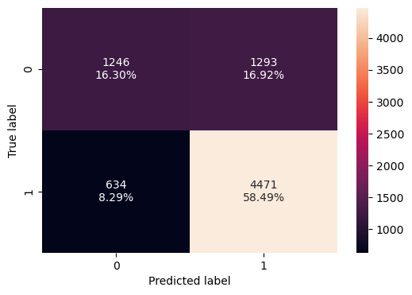

```python
confusion_matrix_sklearn(gbc, X_test,y_test)
```

```python
gbc_model_test_perf=model_performance_classification_sklearn(gbc, X_test, y_test)
print("Testing performance \n",gbc_model_test_perf)
```

```
Testing performance
    Accuracy  Recall  Precision    F1
0     0.748   0.876      0.776 0.823
```

###### Observaciones Clasificador de aumento de gradiente

- El modelo GB de aumento de gradiente, también ha generalizado bien en los datos de entrenamiento y prueba.
- El modelo es más fuerte en Recall (0.88), pero también muestra cierta eficiencia en Precisión ( 0.77)
- El f1_score es de 0.82, lo que implica un modelo aceptable.

### Clasificador XGBoost

```python
xgb = XGBClassifier(random_state=1,eval_metric='logloss')
xgb.fit(X_train,y_train)
```

```
XGBClassifier(base_score=None, booster=None, callbacks=None,
              colsample_bylevel=None, colsample_bynode=None,
              colsample_bytree=None, device=None, early_stopping_rounds=None,
              enable_categorical=False, eval_metric='logloss',
              feature_types=None, gamma=None, grow_policy=None,
              importance_type=None, interaction_constraints=None,
              learning_rate=None, max_bin=None, max_cat_threshold=None,
              max_cat_to_onehot=None, max_delta_step=None, max_depth=None,
              max_leaves=None, min_child_weight=None, missing=nan,
              monotone_constraints=None, multi_strategy=None, n_estimators=None,
              n_jobs=None, num_parallel_tree=None, random_state=1, ...)
```

##### Revisión del rendimiento en el conjunto de entrenamiento

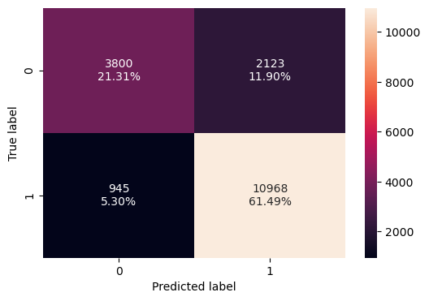

```python
confusion_matrix_sklearn(xgb, X_train,y_train)
```

```python
xgb_model_train_perf=model_performance_classification_sklearn(xgb, X_train,y_train)
print("Training performance \n",xgb_model_train_perf)
```

```
Training performance
    Accuracy  Recall  Precision    F1
0     0.828   0.921      0.838 0.877
```

##### Revisión del rendimiento en el conjunto de prueba

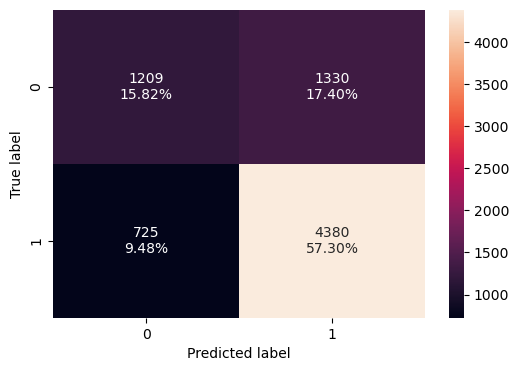

```python
confusion_matrix_sklearn(xgb, X_test,y_test)
```

```python
xgb_model_test_perf=model_performance_classification_sklearn(xgb, X_test, y_test)
print("Testing performance \n",xgb_model_test_perf)
```

```
Testing performance
    Accuracy  Recall  Precision    F1
0     0.731   0.858      0.767 0.810
```

## Ajuste de hiperparámetros BOOSTING

### Clasificador AdaBoost ajustado

En el ajuste de hiperparámetros para AdaBost , algunos términos importantes son:

**base_estimator:** Este es el tipo de clasificador débil que se usa como punto de partida. Por defecto, se utiliza un árbol de decisión muy simple.

**n_estimators:** Este es el número máximo de clasificadores débiles que se ajustarán. El valor predeterminado es 50.

**learning_rate:** La tasa de aprendizaje controla cuánto se ajustan los pesos de los ejemplos en cada ronda. Hay un equilibrio entre la tasa de aprendizaje y el número de clasificadores débiles utilizados.

```python
%%time
# Choose the type of classifier.
abc_tuned = AdaBoostClassifier(random_state=1)

# Grid of parameters to choose from

parameters = {

    "base_estimator":[DecisionTreeClassifier(max_depth=1, random_state=1),
                      DecisionTreeClassifier(max_depth=2, random_state=1),
                      DecisionTreeClassifier(max_depth=3, random_state=1)],
    "n_estimators": np.arange(10,110,10),
    "learning_rate":np.arange(0.1,2,0.1)
}

# Type of scoring used to compare parameter combinations
acc_scorer = metrics.make_scorer(metrics.f1_score)

# Run the grid search
grid_obj = GridSearchCV(abc_tuned, parameters, scoring=acc_scorer,cv=5, n_jobs = -1)
grid_obj = grid_obj.fit(X_train, y_train)

# Set the clf to the best combination of parameters
abc_tuned = grid_obj.best_estimator_

# Fit the best algorithm to the data.
abc_tuned.fit(X_train, y_train)
```

```
CPU times: total: 19.1 s
Wall time: 5min 43s
```

```
AdaBoostClassifier(base_estimator=DecisionTreeClassifier(max_depth=3,
                                                         random_state=1),
                   learning_rate=0.1, random_state=1)
```

##### Revisión del rendimiento en el conjunto de entrenamiento

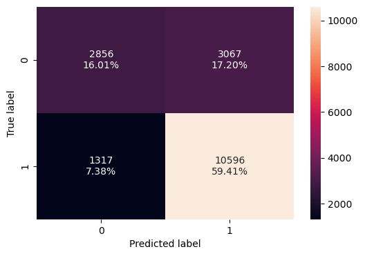

```python
confusion_matrix_sklearn(abc_tuned, X_train,y_train)
```

```python
abc_tuned_model_train_perf=model_performance_classification_sklearn(abc_tuned, X_train,y_train)
print("Training performance \n",abc_tuned_model_train_perf)
```

```
Training performance
    Accuracy  Recall  Precision    F1
0     0.754   0.889      0.776 0.829
```

##### Revisión del rendimiento en el conjunto de prueba

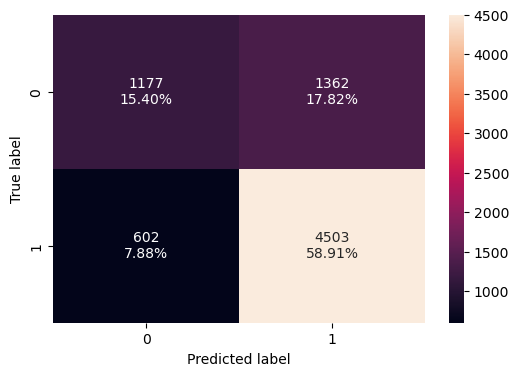

```python
confusion_matrix_sklearn(abc_tuned, X_test,y_test)
```

```python
abc_tuned_model_test_perf=model_performance_classification_sklearn(abc_tuned, X_test, y_test)
print("Testing performance \n",abc_tuned_model_test_perf)
```

```
Testing performance
    Accuracy  Recall  Precision    F1
0     0.743   0.882      0.768 0.821
```

###### Observaciones Clasificador AdaBoost ajustado

- El modelo AdaBoost Boost ajustado no muestra gran diferencia con el modelo sin ajustar.
- Este modelo generaliza bien en los datos de entrenamiento y prueba.
- La métrica de interés es f1_score de 0.82, no obstante el modelo es más fuerte en Recall (0.88).

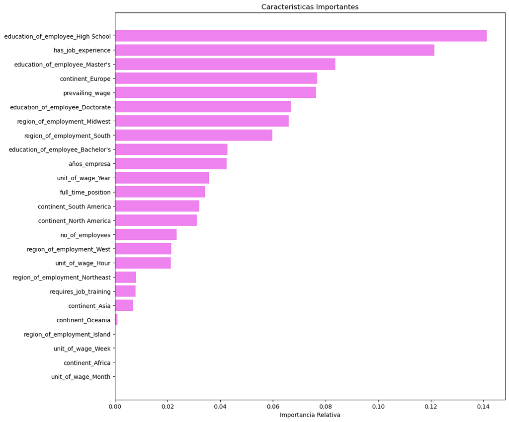

```python
#Visualización de carcteristicas importantes Clasificador AdaBoost ajustado
importances = abc_tuned.feature_importances_
indices = np.argsort(importances)
feature_names = list(X.columns)

plt.figure(figsize=(12,12))
plt.title('Caracteristicas Importantes')
plt.barh(range(len(indices)), importances[indices], color='violet', align='center')
plt.yticks(range(len(indices)), [feature_names[i] for i in indices])
plt.xlabel('Importancia Relativa')
plt.show()
```

**De las caracteristicas importante que destaca este modelo:**

- La educación del empleado_ High School es la característica más importante según el modelo tuned AdaBoost.
- Seguido de contar experiencia previa para trabajar, La educación del empleado_ Master, y que la solicitud provenga de Europa, así como el salario prevaleciente. En ese orden.